# SVM Classification of Obesity Levels

## Goal and data

We classify the seven-level `NObeyesdad` outcome from the other 16 predictors in the [UCI obesity dataset](https://doi.org/10.24432/C5H31Z). The 2,111 records have no missing values; class counts range from 272 to 351. Nominal predictors are dummy-coded; ordered `CAEC` and `CALC` use ordered-factor contrasts. A linear kernel tests a straight boundary in the encoded predictors; polynomial and radial kernels allow nonlinear boundaries. UCI reports that 77% of records were synthetically generated, so strong performance may not generalize to independently collected populations.

## Tuning and selection

With seed 43201, reserve a stratified 20% test set, used only once after model selection. Compare 15 settings with the same stratified five folds on the remaining data: linear, polynomial (degrees 2 and 3), and radial kernels. Tune cost `C`, which penalizes margin violations; for radial kernels also tune `gamma`, which controls boundary locality. Polynomial `gamma = 1/p` and `coef0 = 1`, where `p` is the encoded predictor count. Within each fold, center and scale encoded predictors using that fold’s training data only. Select the setting with the lowest mean cross-validation misclassification rate and compare it with a majority-class baseline.

**Show analysis code**

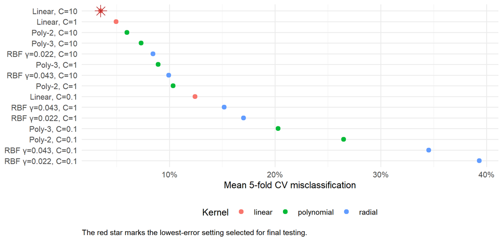

```r
library(e1071)
library(ggplot2)
library(knitr)

data_file <- if (file.exists(file.path("data", "ObesityDataSet_raw_and_data_sinthetic.csv"))) {
  file.path("data", "ObesityDataSet_raw_and_data_sinthetic.csv")
} else {
  file.path("project", "data", "ObesityDataSet_raw_and_data_sinthetic.csv")
}
df <- read.csv(data_file, stringsAsFactors = FALSE)

class_levels <- c(
  "Insufficient_Weight", "Normal_Weight", "Overweight_Level_I",
  "Overweight_Level_II", "Obesity_Type_I", "Obesity_Type_II",
  "Obesity_Type_III"
)
df$NObeyesdad <- factor(df$NObeyesdad, levels = class_levels)
stopifnot(!anyNA(df))

nominal <- c(
  "Gender", "family_history_with_overweight", "FAVC",
  "SMOKE", "SCC", "MTRANS"
)
df[nominal] <- lapply(df[nominal], factor)
df$CAEC <- ordered(df$CAEC, levels = c("no", "Sometimes", "Frequently", "Always"))
df$CALC <- ordered(df$CALC, levels = c("no", "Sometimes", "Frequently", "Always"))

y <- df$NObeyesdad
predictor_data <- df[, setdiff(names(df), "NObeyesdad"), drop = FALSE]
X <- model.matrix(~ ., data = predictor_data)[, -1, drop = FALSE]
p <- ncol(X)

set.seed(43201)
test_index <- unlist(lapply(class_levels, function(cl) {
  rows <- which(y == cl)
  sample(rows, size = floor(0.2 * length(rows)))
}), use.names = FALSE)
train_index <- setdiff(seq_along(y), test_index)

fold_id <- integer(length(train_index))
y_train <- y[train_index]
for (cl in class_levels) {
  rows <- which(y_train == cl)
  fold_id[rows] <- sample(rep(seq_len(5), length.out = length(rows)))
}

grid <- rbind(
  data.frame(kernel = "linear", degree = NA_integer_,
             cost = c(0.1, 1, 10), gamma = NA_real_),
  expand.grid(kernel = "polynomial", degree = 2:3,
              cost = c(0.1, 1, 10), gamma = NA_real_),
  expand.grid(kernel = "radial", degree = NA_integer_,
              cost = c(0.1, 1, 10), gamma = c(0.5 / p, 1 / p))
)
grid$cv_error <- NA_real_
fold_errors <- matrix(NA_real_, nrow = 5, ncol = nrow(grid))
fold_baseline_errors <- numeric(5)

standardize_from <- function(train, other) {
  center <- colMeans(train)
  spread <- apply(train, 2, sd)
  spread[!is.finite(spread) | spread == 0] <- 1
  list(
    train = sweep(sweep(train, 2, center, "-"), 2, spread, "/"),
    other = sweep(sweep(other, 2, center, "-"), 2, spread, "/")
  )
}

fit_candidate <- function(x, response, setting) {
  args <- list(
    x = x, y = droplevels(response),
    kernel = as.character(setting$kernel),
    cost = setting$cost, scale = FALSE
  )
  if (setting$kernel == "polynomial") {
    args$degree <- setting$degree
    args$gamma <- 1 / p
    args$coef0 <- 1
  }
  if (setting$kernel == "radial") args$gamma <- setting$gamma
  do.call(e1071::svm, args)
}

for (fold in seq_len(5)) {
  fold_train <- train_index[fold_id != fold]
  fold_valid <- train_index[fold_id == fold]
  majority_class <- names(which.max(table(y[fold_train])))
  fold_baseline_errors[fold] <- mean(y[fold_valid] != majority_class)
  transformed <- standardize_from(X[fold_train, , drop = FALSE],
                                  X[fold_valid, , drop = FALSE])

  for (j in seq_len(nrow(grid))) {
    fit <- fit_candidate(transformed$train, y[fold_train], grid[j, ])
    pred <- predict(fit, transformed$other)
    fold_errors[fold, j] <- mean(pred != y[fold_valid])
  }
}

grid$cv_error <- colMeans(fold_errors)
baseline_cv_error <- mean(fold_baseline_errors)
grid$selected <- ""
best_index <- which.min(grid$cv_error)
grid$selected[best_index] <- "Yes"

candidate_label <- function(row) {
  kernel <- switch(as.character(row$kernel),
    linear = "Linear",
    polynomial = paste0("Poly-", row$degree),
    radial = paste0("RBF \u03b3=", signif(row$gamma, 2))
  )
  paste0(kernel, ", C=", row$cost)
}
grid$candidate <- vapply(seq_len(nrow(grid)), function(i) {
  candidate_label(grid[i, ])
}, character(1))

plot_data <- grid
plot_data$candidate <- factor(
  plot_data$candidate,
  levels = plot_data$candidate[order(plot_data$cv_error, decreasing = TRUE)]
)
ggplot(plot_data, aes(x = candidate, y = cv_error, color = kernel)) +
  geom_point(size = 2) +
  geom_point(
    data = plot_data[best_index, , drop = FALSE],
    shape = 8, size = 4, color = "firebrick"
  ) +
  coord_flip() +
  scale_y_continuous(labels = scales::label_percent(accuracy = 1)) +
  labs(
    x = NULL, y = "Mean 5-fold CV misclassification",
    color = "Kernel",
    caption = "The red star marks the lowest-error setting selected for final testing."
  ) +
  theme_minimal(base_size = 10) +
  theme(
    legend.position = "bottom",
    plot.caption = element_text(hjust = 0, size = 8),
    axis.text.y = element_text(size = 8.5),
    axis.text.x = element_text(size = 8.5)
  )
```

**Show analysis code**

```r
report_grid <- data.frame(
  Model = grid$candidate,
  `CV error` = sprintf("%.3f", grid$cv_error),
  Selected = grid$selected,
  check.names = FALSE
)
kable(report_grid, align = c("l", "r", "c"))
```

| Model | CV error | Selected |
| --- | --- | --- |
| Linear, C=0.1 | 0.124 |  |
| Linear, C=1 | 0.050 |  |
| Linear, C=10 | 0.035 | Yes |
| Poly-2, C=0.1 | 0.265 |  |
| Poly-3, C=0.1 | 0.203 |  |
| Poly-2, C=1 | 0.103 |  |
| Poly-3, C=1 | 0.089 |  |
| Poly-2, C=10 | 0.060 |  |
| Poly-3, C=10 | 0.073 |  |
| RBF γ=0.022, C=0.1 | 0.393 |  |
| RBF γ=0.022, C=1 | 0.170 |  |
| RBF γ=0.022, C=10 | 0.085 |  |
| RBF γ=0.043, C=0.1 | 0.345 |  |
| RBF γ=0.043, C=1 | 0.152 |  |
| RBF γ=0.043, C=10 | 0.099 |  |

**Selected setting:** Linear, C=10 (mean CV error 0.035). The majority-class baseline has mean CV error 0.834.

## Held-out evaluation

Refit the selected setting on the complete training set, then evaluate once on the reserved test set. The table reports one-vs-rest counts for each class; because this is a seven-class task, TN/FP/FN/TP are class-specific.

**Show analysis code**

```r
final_transform <- standardize_from(
  X[train_index, , drop = FALSE],
  X[test_index, , drop = FALSE]
)
final_fit <- fit_candidate(final_transform$train, y[train_index],
                           grid[best_index, ])
test_pred <- factor(
  predict(final_fit, final_transform$other),
  levels = class_levels
)
test_truth <- factor(y[test_index], levels = class_levels)
test_majority_class <- names(which.max(table(y[train_index])))
baseline_test_accuracy <- mean(test_truth == test_majority_class)
confusion <- table(Actual = test_truth, Predicted = test_pred)

tp <- diag(confusion)
fn <- rowSums(confusion) - tp
fp <- colSums(confusion) - tp
tn <- sum(confusion) - tp - fn - fp
ovr <- data.frame(Class = class_levels, TN = tn, FP = fp, FN = fn, TP = tp)
rownames(ovr) <- NULL

test_accuracy <- mean(test_pred == test_truth)
macro_recall <- mean(tp / (tp + fn))

kable(ovr, row.names = FALSE, align = c("l", "r", "r", "r", "r"))
```

| Class | TN | FP | FN | TP |
| --- | --- | --- | --- | --- |
| Insufficient_Weight | 364 | 2 | 1 | 53 |
| Normal_Weight | 359 | 4 | 2 | 55 |
| Overweight_Level_I | 360 | 2 | 5 | 53 |
| Overweight_Level_II | 359 | 3 | 2 | 56 |
| Obesity_Type_I | 350 | 0 | 3 | 67 |
| Obesity_Type_II | 359 | 2 | 0 | 59 |
| Obesity_Type_III | 356 | 0 | 0 | 64 |

The selected model’s held-out accuracy is **0.969** (13 errors among 420 cases), versus **0.167** for the majority-class baseline; macro-averaged sensitivity is **0.969**. The one-vs-rest counts show which categories are confused. These results estimate performance on one stratified split, not independently collected populations; the dataset is predominantly synthetic, and weight/height are closely associated with obesity class.